# Zurich Report

2026-03-20

## Introduction

An essential part of oncological research is based on survival analysis, as one of the main goals is to reduce mortality in patients, as well as increase the time without disease progression. Overall survival (OS), defined as the time from randomisation to death, is seen as the gold standard in oncology clinical trials, as it is easy to measure, since we usually have a precise time for death. It is also very objective, as death is a well-defined endpoint and its measurement cannot be biased by the researcher’s assessment. Moreover, the censoring rules, which are the set of scenarios that describe when a patient will be censored, employed in the analysis of OS tend to be simple and consistent among trials, reducing the possibility of bias. At the same time, OS requires very long follow-up periods and its usefulness is limited in the case of slow-progressing diseases with a long survival expectancy, as there is a high chance of intercurrent events or changes in treatment.

These are some of the reasons why tumour-based endpoints are also widely accepted. Among the most common ones, there are:

- Progression-Free Survival (PFS), defined as the time from randomisation until the first evidence of disease progression or death.
- Disease-Free Survival (DFS), defined as the time from randomisation until evidence of disease recurrence.
- Event-Free Survival (EFS), defined as the time from randomisation to an event which may include disease progression, discontinuation of the treatment for any reason, or death.
- Relapse-Free Survival (RFS), defined as the length of time after primary treatment that the patient survives without any signs or symptoms of that cancer.

The choice of tumour-based endpoint depends on the type of tumour studied, but they are all subject to the possibility of bias. Therefore, their use is more controversial compared with OS, due to the subjectivity of tumour assessment. These endpoints also rely more on how different scenarios are accounted for as that can affect whether some and until which points some patients are included in the analyses. This means that they are more prone to obtaining different results depending on the type of primary analysis and censoring rules employed, and, therefore, to bias.

To evaluate how dependent the primary results are on methodological choices and assess their robustness and the potential impact of bias, sensitivity analyses are often employed. These analyses reassess study outcomes with varying methodologies, assumptions, and/or censoring rules. However, the choice of which primary and sensitivity analyses to include in the study remains a subjective one.

Our main project aims to:

1. Assess the reproducibility of the main studies that supported European Medicine Agency (EMA) authorisations of indications for oncological drugs.
2. Evaluate the robustness of the selected studies’ conclusions using different censoring rules.
3. Analyse, when possible, the difference in results between the primary and the sensitivity analyses to identify possible trends in the choice of primary analyses In this report we focus on this last point of the project.

## Methods

We identified all oncologic indications that received a positive opinion from the Committee for Medicinal Products for Human Use (CHMP) between January 01, 2020 and December 31, 2024. Using the European public assessment report (EPAR), we then identified 223 randomised controlled trials (RCTs) referred to as ‘main studies’.

We used the results of an earlier audit of data sharing by pharmaceutical companies for oncology trials, to calculate the size of the sample needed for our study. This previous paper found that only 34% of trials that supported FDA approval between 2011 and 2021 had accessible IPD. We used 34% as the expected proportion of reproducible trials and 12% as the half-width of the 95% CI and obtained 60 trials as required sample size for our study. Therefore we selected 60 RCTs using the sampling function implemented in R, setting a seed for computational reproducibility.

During the review of the documents of the selected trials, it was noticed that two of them did not report any analyses for neither OS nor any tumour based endpoint. They were removed from the sample and two more were randomly selected using the same function and seed but removing the already selected studies from the pool of selectable studies.

For each selected RCT, we have requested the relevant document to reanalyse the original results. We have also collected the publicly available information on the type of primary and sensitivity analyses conducted in each RCT through EPARs, journal articles and their supplementary materials, Protocols and SAPs; extracting their results in terms of Hazard Ratios (HRs) and confidence intervals (CIs) for OS and tumour-based endpoints, for each analysis in each RCT.

### Data extraction

We created an [Excel file](https://uniren1-my.sharepoint.com/:x:/g/personal/giulia_varvara_univ-rennes_fr/EYIBktM27lhIvCf4wRn-030BDRcOL2O7wJAb2NL6Ws71Hw?e=XwaLyy) containing, for each RCT, information about the main time-to-event endpoint analysed, the type of primary and sensitivity analyses reported in any of the publicly available documents, the censoring rules employed and the values for HRs, lower and upper bounds of the Confidence Intervals, $p$-value and, when possible, the median survival time.

For simplification, all the different tumour-based endpoints, like Progression-Free Survival (PFS), Disease-Free Survival (DFS), Relapse-Free Survival (RFS) etc. were grouped under the label of Tumour-Based Endpoint (TBE) for the purpose of our analyses.

Moreover, sensitivity analyses were divided into three categories according to the type of sensitivity analysis. Sensitivity analyses were categorised as “Censoring rules” when the main difference with the primary analysis was the set of censoring rules defining in which situations patients should be censored and how their data should be included in the analysis. They were defined as changes in “Population” when the sensitivity analysis was focusing on a different population or a subset of the primary analysis’s population.

Finally, they were classified as differing in “Methods” when different types of analysis, stratification or evaluation of tumour growth were employed.

The number of sensitivity analyses per category for each point is reported in the following table, from which it is also possible to see that some sensitivity analyses fell under more than one category.

|  | Censoring | Censoring, Methods | Methods | Methods, Population | Population |
| --- | --- | --- | --- | --- | --- |
| TBE | 97 | 8 | 69 | 2 | 15 |
| OS | 5 | 0 | 37 | 0 | 4 |

Also, the same study could have multiple sensitivity analyses, and those could belong to different categories. The following figure shows how many studies have sensitivity analysis across how many different categories.

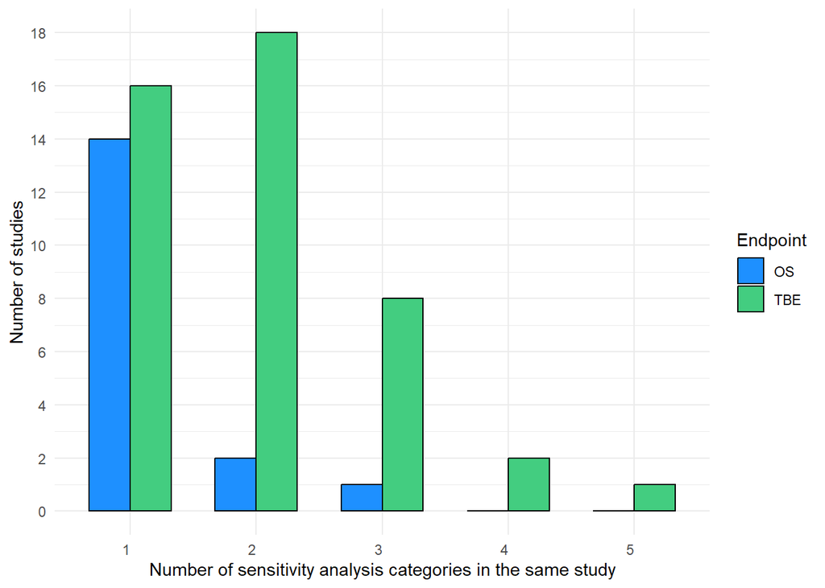

For example, the sensitivity analysis of an RCT could change the evaluation method from an Independent Review Committee (IRC) to an Investigator based one, but at the same time focus on the Per-Protocol population instead of the population that the primary analysis was focused on; in this case the sensitivity analysis would be classified as both “Methods” and “Population” based.

We used these data collected from the public records to create forest plots of the results for each RCT, and we combined them in an external pdf.

To have a better idea of the amount of sensitivity analysis used per RCT, we plotted their frequency per endpoint. For simplification, all the different tumour-based endpoints such as Progression-Free Survival (PFS), Disease-Free Survival (DFS), Relapse-Free Survival (RFS) etc. were grouped under the label of Tumour-Based Endpoint (TBE) in our analyses. Then we proceeded to use the extracted information to compare the results from the primary analyses with the ones obtained in the sensitivity analyses in each RCT.

All the files and code used for this project are available on [GitHub](https://github.com/GVarv/Zurich-project)

### Analysis comparison per trial

To identify whether there was any pattern in the choice of primary or sensitivity analysis, we compared the results from each of the reported analyzes retrieving the standard errors of the log of each HR using the function from the R package and then computed the ratio between the standard errors of the sensitivity analyzes and the one of the primary analyzes. Similarly, we computed the logarithm of the ratio of the HR of the sensitivity analysis over the HR of the primary analysis.

We then examined the distribution of these quantities for each endpoint and, to examine the possibility of a relation between the comparison of HRs and standard error between sensitivity and primary analyzes, we plotted the ratio of the standard errors computed before against the logarithm of the ratio of HRs.

Afterwards, we tested whether the category of sensitivity analysis that we selected beforehand could influence the model results. So, we added the different categories as a fixed variable in the model. Since some sensitivity analyzes fell under multiple categories at once, we created 3 dummy variables to indicate the presence or absence of change in each category.

Finally, we expanded the previous models to account for the presence of clustering, as in the dataset, multiple data points come from the same RCT, using a mixed model and compared the results of these different analyzes.

## Results

### Sensitivity analysis frequency

The following figure illustrates the frequency of the number of sensitivity analyses per endpoint.

It includes only the analyses that reported numerical values, but 14 analyses coming from 10 RCTs were described in the public documents, but did not have any results described.

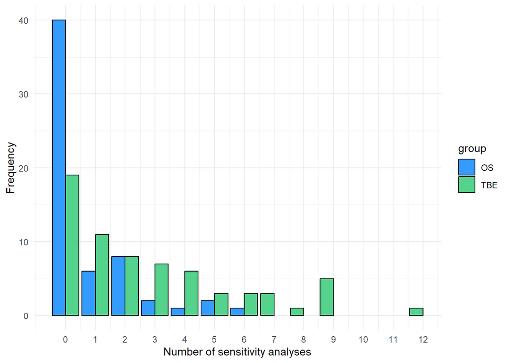

It is worth noticing that the number of studies that do not report any sensitivity analysis at all is quite high for both endpoints. 40 studies did not report any sensitivity analysis for OS and 19 did not report any sensitivity analyses for TBE. The fact that $\frac{2}{3}$ of studies did not have any sensitivity analyses for OS is not surprising, as that is considered a more stable and objective endpoint.\ We then looked at these sensitivity analyses were distributed among the different categories and the results are shown in the next figure.

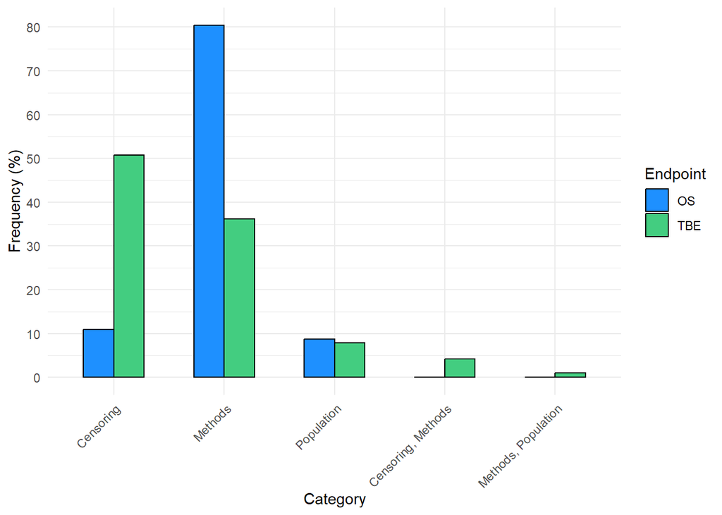

From this histograms, we can see that, while the sensitivity analyses for TBE mostly focused on different censoring rules and slightly less on methods, for OS, the focus of the sensitivity analyses was almost entirely on different methods. In the case of TBE, it is worth keeping in mind that different methods also include changes in the way the disease progression is assessed between investigator-based and Independent Central Review (ICR)-based.

### Hazard ratio and standard error comparison

We then focused on examining the possibility of a pattern in the choice of primary and sensitivity analysis. To do so, we compared the logarithm of HRs and the one of the Standard Errors reported in each trial.

We drew the following boxplot of $\log(\frac{HR_{\scriptsize \mbox{Sensitivity}}}{HR_{\scriptsize \mbox{Primary}}})$ for both OS and the different types of TBE, to see how the differences between primary and sensitivity analyses were distributed

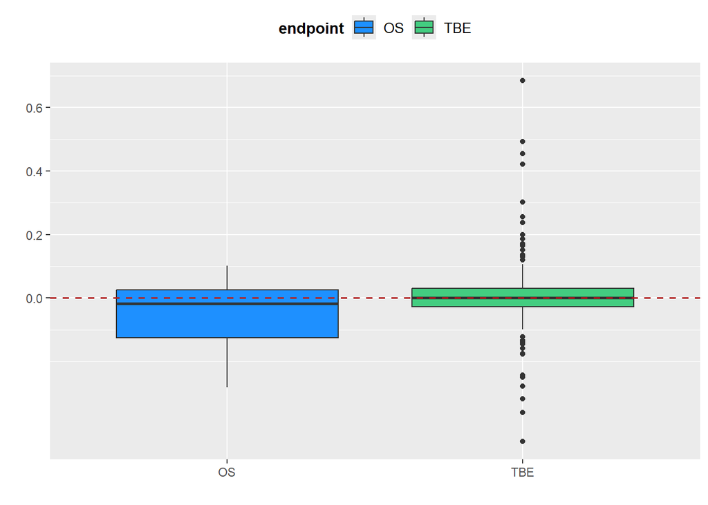

From this boxplot it is possible to see that, while the ratio of HRs in TBE concentrate around 0 with narrow quartiles, there are more outliers than in OS, whose median is slightly below 0 and has wider quartiles, but no outliers. The distributions for TBE and OS were the following:

**TBE**

```r
summary(dif_TBE_clean$log_ratio)
```

```
##      Min.   1st Qu.    Median      Mean   3rd Qu.      Max.
## -0.451985 -0.027034  0.000000  0.008863  0.031164  0.685329
```

**OS**

```r
summary(dif_OS_clean$log_ratio)
```

```
##     Min.  1st Qu.   Median     Mean  3rd Qu.     Max.
## -0.28166 -0.12484 -0.01674 -0.05174  0.02619  0.10245
```

We did the same for the distribution of the standard errors comparison.

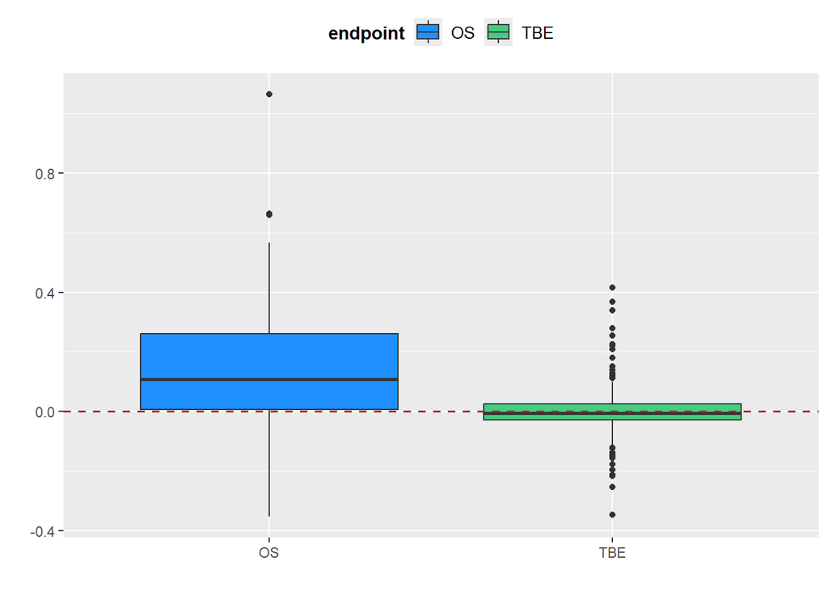

The ratio of standard errors now shows more variability for OS compared to TBE. The ratios vary around 0 for TBE, but tend to be larger 0 for OS. This suggests that the standard errors of sensitivity analyses for OS tend to be larger than the standard errors for the primary analysis. This is not the case for TBE.

To summarise, the distribution of $\log(\frac{SE_{Sensitivity}}{SE_{Primary}})$ is:

**TBE**

```r
summary(dif_TBE_clean$log_se)
```

```
##      Min.   1st Qu.    Median      Mean   3rd Qu.      Max.
## -0.345307 -0.028461 -0.005529  0.001361  0.026220  0.414861
```

**OS**

```r
summary(dif_OS_clean$log_se)
```

```
##      Min.   1st Qu.    Median      Mean   3rd Qu.      Max.
## -0.352382  0.006744  0.108047  0.143540  0.261175  1.063661
```

To examine the possibility of a relationships between the differences in HRs and the differences in standard errors, we plotted $\log\left(\frac{HR_{\scriptsize \mbox{Sensitivity}}}{HR_{\scriptsize \mbox{Primary}}}\right)$ against $\frac{SE_{\scriptsize \mbox{Sensitivity}}}{SE_{\scriptsize \mbox{Primary}}}$ in a scatter plot, where each dot was colored differently according to its NCT, to better visualize the cluster of different trials.

This produced the following scatter plots

[figure not shown]

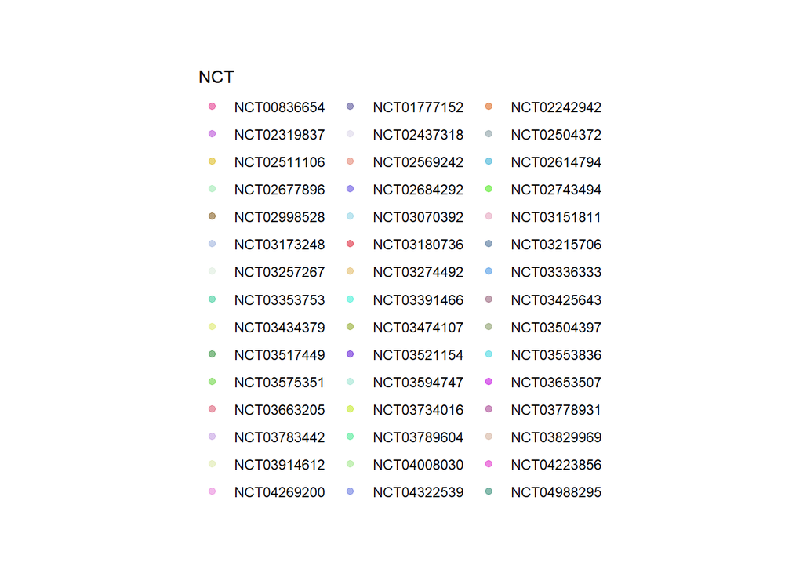

[figure not shown]

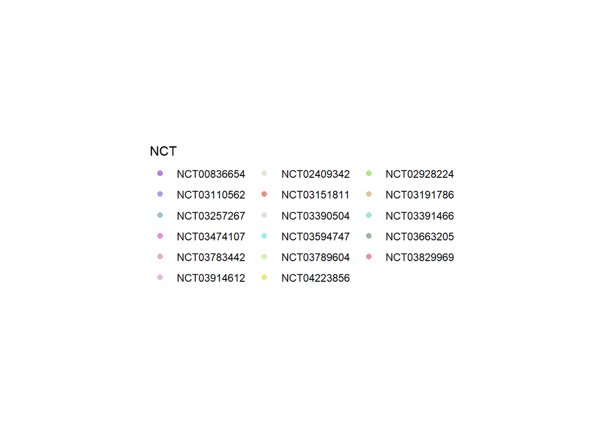

These plots show an interesting pattern: smaller values of the log HRR seem to correspond to larger values of the ratio of standard errors and vice versa. This relationship is further explored through regression analyses.

### Modelling

We proceeded to explore the relationship between HRs and standard error differences using a regression model.

#### Simple linear models

We initially fitted a linear regression model for each endpoint. For **TBE** we obtained the following results:

| F(1,189) | 69.68 |
| --- | --- |
| R² | 0.27 |
| Adj. R² | 0.27 |

|  | Est. | S.E. | t val. | p |
| --- | --- | --- | --- | --- |
| (Intercept) | 0.01 | 0.01 | 1.29 | 0.20 |
| log_se | -0.67 | 0.08 | -8.35 | 0.00 |

Standard errors: OLS

[figure not shown]

```
## [1] -317.62
```

```
## [1] -307.87
```

```
##
## Call:
## lm(formula = log_ratio ~ log_se, data = dif_TBE_clean)
##
## Residuals:
##      Min       1Q   Median       3Q      Max
## -0.38406 -0.04337 -0.00977  0.03108  0.68418
##
## Coefficients:
##              Estimate Std. Error t value Pr(>|t|)
## (Intercept)  0.009769   0.007545   1.295    0.197
## log_se      -0.665764   0.079754  -8.348 1.45e-14 ***
## ---
## Signif. codes:  0 '***' 0.001 '**' 0.01 '*' 0.05 '.' 0.1 ' ' 1
##
## Residual standard error: 0.1043 on 189 degrees of freedom
## Multiple R-squared:  0.2694, Adjusted R-squared:  0.2655
## F-statistic: 69.68 on 1 and 189 DF,  p-value: 1.448e-14
```

There is a significant relationship between the two variables with estimated slope of -0.6657644

This indicates that the ratio in standard errors tends to decrease when the log HR ratio increases.

The same model for **OS** gave the following output:

| F(1,44) | 9.08 |
| --- | --- |
| R² | 0.17 |
| Adj. R² | 0.15 |

|  | Est. | S.E. | t val. | p |
| --- | --- | --- | --- | --- |
| (Intercept) | -0.03 | 0.02 | -1.51 | 0.14 |
| log_se | -0.18 | 0.06 | -3.01 | 0.00 |

Standard errors: OLS

[figure not shown]

```
## [1] -74.77
```

```
## [1] -69.28
```

```
##
## Call:
## lm(formula = log_ratio ~ log_se, data = dif_OS_clean)
##
## Residuals:
##      Min       1Q   Median       3Q      Max
## -0.23682 -0.01440  0.03962  0.06242  0.13003
##
## Coefficients:
##             Estimate Std. Error t value Pr(>|t|)
## (Intercept) -0.02625    0.01736  -1.512  0.13774
## log_se      -0.17762    0.05893  -3.014  0.00427 **
## ---
## Signif. codes:  0 '***' 0.001 '**' 0.01 '*' 0.05 '.' 0.1 ' ' 1
##
## Residual standard error: 0.1028 on 44 degrees of freedom
## Multiple R-squared:  0.1711, Adjusted R-squared:  0.1523
## F-statistic: 9.085 on 1 and 44 DF,  p-value: 0.004266
```

#### Finite Mixture Model (FMM)

The scatter plot for both OS and TBE seemed to also suggest the possibility of two different regression lines, so we also examined this possibility using finite mixture models (FMM). Since the scatter plot suggested only two different distribution, we built a model with two components.

Among the sensitivity analyses for TBE, we obtained the components with sizes 62, 129. The estimates, standard error and $p$-values for the different component are reported in the following table:

```
##
## Call:
## flexmix(formula = log_ratio ~ log_se, data = dif_TBE_clean, k = 2,
##     control = list(nrep = 10))
##
##        prior size post>0 ratio
## Comp.1 0.414   62    191 0.325
## Comp.2 0.586  129    158 0.816
##
## 'log Lik.' 223.8395 (df=7)
## AIC: -433.679   BIC: -410.9131
```

| Variable | Component 1 Estimate | Component 1 Std. Error | Component 1 P-value | Component 2 Estimate | Component 2 Std. Error | Component 2 P-value |
| --- | --- | --- | --- | --- | --- | --- |
| (Intercept) | 0.02171 | 0.01666 | 0.19255 | -0.00258 | 0.00311 | 0.40654 |
| log_se | -0.92274 | 0.13253 | 0 | 0.03585 | 0.04999 | 0.47323 |

```
##      Variable Estimate Std. Error P-value Estimate Std. Error P-value
## 1 (Intercept)  0.02171    0.01666 0.19255 -0.00258    0.00311 0.40654
## 2      log_se -0.92274    0.13253       0  0.03585    0.04999 0.47323
```

These results show a very strong difference in the strength of the estimate for the logarithm of the ratio between the components. To visualize these results, we plotted the regression lines for both components on the scatter plot

[figure not shown]

```
## [1] 19
```

```
## [1] 26
```

We then examined the component assignment in the different category of sensitivity analysis to see if it was possible to identify a pattern.

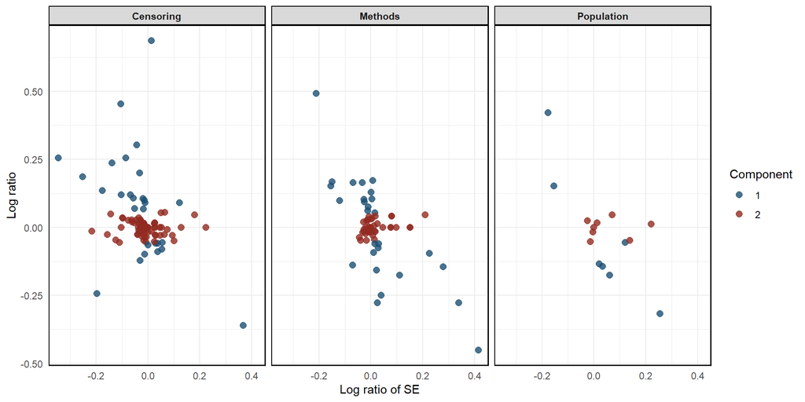

For **OS** the FMM distribution between component was:

```
##
## Call:
## flexmix(formula = log_ratio ~ log_se, data = dif_OS_clean, k = 2)
##
##        prior size post>0 ratio
## Comp.1 0.253   12     38 0.316
## Comp.2 0.747   34     38 0.895
##
## 'log Lik.' 62.07819 (df=7)
## AIC: -110.1564   BIC: -97.35589
```

| Variable | Component 1 Estimate | Component 1 Std. Error | Component 1 P-value | Component 2 Estimate | Component 2 Std. Error | Component 2 P-value |
| --- | --- | --- | --- | --- | --- | --- |
| (Intercept) | -0.22207 | 0.03557 | 0 | 0.02545 | 0.00653 | 1e-04 |
| log_se | 0.0735 | 0.13613 | 0.58925 | -0.17832 | 0.02105 | 0 |

[figure not shown]

We also plotted the component assignment for the different categories of sensitivity analyses:

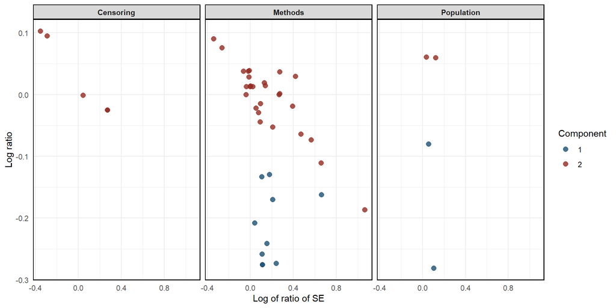

Afterwards we looked at the posterior probability of inclusion according to each category, for both TBE and OS. The relative boxplots are shown in the following figures. The mean for each category is also reported as a black line.

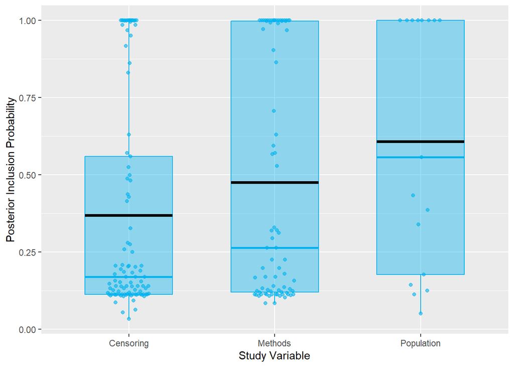

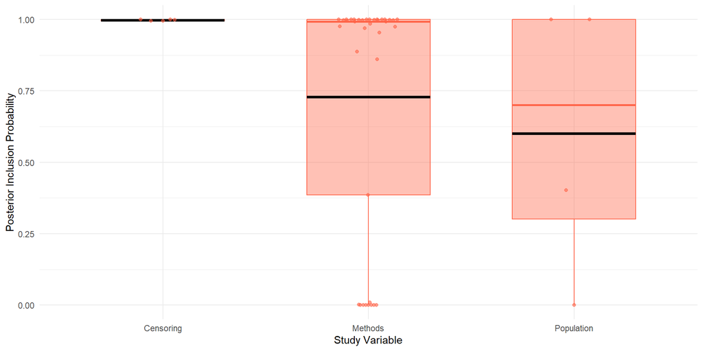

#### Linear model with covariates

The boxplots in the previous section suggested that the category of sensitivity analysis has an impact on the model results.

Changing censoring rules could have an impact on both the number of events and of people at risk at various time, modifying both the HR and standard errors. This is because censoring more individuals reduces the number of people at risk and at prevent any event that these individuals might have had to be included in the analysis. Also, if informative censoring is present, this will impact one arm more than the other, changing between the balance between the number of events in the different arms.

Similarly, using different population for the analysis can also change the relationship between the number of people at risk and the number of events in each arm, which might also impact the standard errors and the HR.

This covariates model for **TBE** gave the following results:

| F(7,183) | 11.44 |
| --- | --- |
| R² | 0.30 |
| Adj. R² | 0.28 |

|  | Est. | S.E. | t val. | p |
| --- | --- | --- | --- | --- |
| (Intercept) | 0.01 | 0.04 | 0.23 | 0.82 |
| log_se | -0.56 | 0.26 | -2.18 | 0.03 |
| CensoringYes | 0.00 | 0.04 | 0.13 | 0.90 |
| MethodsYes | 0.00 | 0.03 | 0.14 | 0.89 |
| PopulationYes | 0.01 | 0.04 | 0.15 | 0.88 |
| log_se:CensoringYes | 0.14 | 0.25 | 0.58 | 0.56 |
| log_se:MethodsYes | -0.15 | 0.21 | -0.70 | 0.48 |
| log_se:PopulationYes | -0.42 | 0.25 | -1.66 | 0.10 |

Standard errors: OLS

```
## [1] -315.01
```

```
## [1] -285.74
```

```
##
## Call:
## lm(formula = log_ratio ~ log_se * Censoring + log_se * Methods +
##     log_se * Population, data = dif_TBE_clean)
##
## Residuals:
##      Min       1Q   Median       3Q      Max
## -0.33840 -0.04132 -0.01315  0.03925  0.67756
##
## Coefficients:
##                       Estimate Std. Error t value Pr(>|t|)
## (Intercept)           0.008509   0.036708   0.232   0.8169
## log_se               -0.560607   0.257150  -2.180   0.0305 *
## CensoringYes          0.004645   0.035865   0.130   0.8971
## MethodsYes            0.004679   0.034440   0.136   0.8921
## PopulationYes         0.006494   0.042846   0.152   0.8797
## log_se:CensoringYes   0.144765   0.248546   0.582   0.5610
## log_se:MethodsYes    -0.146843   0.208526  -0.704   0.4822
## log_se:PopulationYes -0.415210   0.250219  -1.659   0.0988 .
## ---
## Signif. codes:  0 '***' 0.001 '**' 0.01 '*' 0.05 '.' 0.1 ' ' 1
##
## Residual standard error: 0.1034 on 183 degrees of freedom
## Multiple R-squared:  0.3044, Adjusted R-squared:  0.2778
## F-statistic: 11.44 on 7 and 183 DF,  p-value: 5.167e-12
```

The results for same model for **OS** were the following:

| F(5,40) | 2.12 |
| --- | --- |
| R² | 0.21 |
| Adj. R² | 0.11 |

|  | Est. | S.E. | t val. | p |
| --- | --- | --- | --- | --- |
| (Intercept) | 0.02 | 0.13 | 0.14 | 0.89 |
| log_se | -0.97 | 1.51 | -0.65 | 0.52 |
| CensoringYes | 0.01 | 0.14 | 0.06 | 0.95 |
| MethodsYes | -0.05 | 0.13 | -0.40 | 0.69 |
| PopulationYes | NA | NA | NA | NA |
| log_se:CensoringYes | 0.76 | 1.52 | 0.50 | 0.62 |
| log_se:MethodsYes | 0.82 | 1.51 | 0.54 | 0.59 |
| log_se:PopulationYes | NA | NA | NA | NA |

Standard errors: OLS

```
## [1] -68.95
```

```
## [1] -56.15
```

```
##
## Call:
## lm(formula = log_ratio ~ log_se * Censoring + log_se * Methods +
##     log_se * Population, data = dif_OS_clean)
##
## Residuals:
##      Min       1Q   Median       3Q      Max
## -0.22299 -0.02332  0.02767  0.07014  0.16219
##
## Coefficients: (2 not defined because of singularities)
##                       Estimate Std. Error t value Pr(>|t|)
## (Intercept)           0.018250   0.132764   0.137    0.891
## log_se               -0.971249   1.505120  -0.645    0.522
## CensoringYes          0.008252   0.140888   0.059    0.954
## MethodsYes           -0.053491   0.134370  -0.398    0.693
## PopulationYes               NA         NA      NA       NA
## log_se:CensoringYes   0.758361   1.515450   0.500    0.620
## log_se:MethodsYes     0.816661   1.506582   0.542    0.591
## log_se:PopulationYes        NA         NA      NA       NA
##
## Residual standard error: 0.1053 on 40 degrees of freedom
## Multiple R-squared:  0.2094, Adjusted R-squared:  0.1106
## F-statistic:  2.12 on 5 and 40 DF,  p-value: 0.08289
```

##### Primary HR as regression variable

```r
mHR_TBE= lm(log_ratio ~ log_se * log(ref_HR), data = dif_TBE_clean)
summary(mHR_TBE)
```

```
##
## Call:
## lm(formula = log_ratio ~ log_se * log(ref_HR), data = dif_TBE_clean)
##
## Residuals:
##      Min       1Q   Median       3Q      Max
## -0.31271 -0.03760 -0.00130  0.03638  0.65252
##
## Coefficients:
##                    Estimate Std. Error t value Pr(>|t|)
## (Intercept)        -0.03535    0.01456  -2.428 0.016125 *
## log_se             -0.26866    0.18072  -1.487 0.138795
## log(ref_HR)        -0.06977    0.01876  -3.719 0.000264 ***
## log_se:log(ref_HR)  0.51944    0.19690   2.638 0.009041 **
## ---
## Signif. codes:  0 '***' 0.001 '**' 0.01 '*' 0.05 '.' 0.1 ' ' 1
##
## Residual standard error: 0.1004 on 187 degrees of freedom
## Multiple R-squared:  0.3297, Adjusted R-squared:  0.3189
## F-statistic: 30.66 on 3 and 187 DF,  p-value: 3.629e-16
```

```r
mHR_OS= lm(log_ratio ~ log_se * log(ref_HR), data = dif_OS_clean) #Remove methods
summary(mHR_OS)
```

```
##
## Call:
## lm(formula = log_ratio ~ log_se * log(ref_HR), data = dif_OS_clean)
##
## Residuals:
##      Min       1Q   Median       3Q      Max
## -0.21429 -0.02658  0.02541  0.06910  0.13307
##
## Coefficients:
##                    Estimate Std. Error t value Pr(>|t|)
## (Intercept)        -0.11085    0.04331  -2.559   0.0142 *
## log_se             -0.12335    0.16459  -0.749   0.4578
## log(ref_HR)        -0.24860    0.11697  -2.125   0.0395 *
## log_se:log(ref_HR)  0.11659    0.49745   0.234   0.8158
## ---
## Signif. codes:  0 '***' 0.001 '**' 0.01 '*' 0.05 '.' 0.1 ' ' 1
##
## Residual standard error: 0.09773 on 42 degrees of freedom
## Multiple R-squared:  0.2854, Adjusted R-squared:  0.2344
## F-statistic: 5.592 on 3 and 42 DF,  p-value: 0.002552
```

#### Random effect models

Since multiple points of the dataset come from the same RCT, we also fitted a random effect model with the RCT ID as random intercept, in order to take into account the effect that this clustering could have on the analysis

For the different **TBE**, the results are:

| AIC | -313.68 |
| --- | --- |
| BIC | -300.68 |
| Pseudo-R² (fixed effects) | 0.23 |
| Pseudo-R² (total) | 0.50 |

| Fixed Effects | Fixed Effects Est. | Fixed Effects S.E. | Fixed Effects t val. | Fixed Effects d.f. | Fixed Effects p |
| --- | --- | --- | --- | --- | --- |
| (Intercept) | 0.01 | 0.01 | 0.99 | 14.51 | 0.34 |
| log_se | -0.64 | 0.08 | -7.79 | 177.96 | 0.00 |

p values calculated using Satterthwaite d.f.

| Random Effects Group | Random Effects Parameter | Random Effects Std. Dev. |
| --- | --- | --- |
| NCT | (Intercept) | 0.07 |
| Residual |  | 0.09 |

| Grouping Variables Group | Grouping Variables # groups | Grouping Variables ICC |
| --- | --- | --- |
| NCT | 45 | 0.35 |

For **OS** the random effect model shows the following results:

| AIC | -63.64 |
| --- | --- |
| BIC | -56.33 |
| Pseudo-R² (fixed effects) | 0.17 |
| Pseudo-R² (total) | 0.30 |

| Fixed Effects | Fixed Effects Est. | Fixed Effects S.E. | Fixed Effects t val. | Fixed Effects d.f. | Fixed Effects p |
| --- | --- | --- | --- | --- | --- |
| (Intercept) | -0.02 | 0.02 | -1.26 | 17.75 | 0.22 |
| log_se | -0.18 | 0.06 | -2.92 | 38.02 | 0.01 |

p values calculated using Satterthwaite d.f.

| Random Effects Group | Random Effects Parameter | Random Effects Std. Dev. |
| --- | --- | --- |
| NCT | (Intercept) | 0.04 |
| Residual |  | 0.09 |

| Grouping Variables Group | Grouping Variables # groups | Grouping Variables ICC |
| --- | --- | --- |
| NCT | 17 | 0.16 |

Then we explore the impact that the type of sensitivity analysis has on the results, adding it as a covariate in the random model.

This interaction model for **TBE** gave the following results:

| AIC | -292.04 |
| --- | --- |
| BIC | -259.52 |
| Pseudo-R² (fixed effects) | 0.26 |
| Pseudo-R² (total) | 0.54 |

| Fixed Effects | Fixed Effects Est. | Fixed Effects S.E. | Fixed Effects t val. | Fixed Effects d.f. | Fixed Effects p |
| --- | --- | --- | --- | --- | --- |
| (Intercept) | 0.04 | 0.04 | 1.16 | 180.70 | 0.25 |
| log_se | -0.61 | 0.23 | -2.70 | 119.02 | 0.01 |
| CensoringYes | -0.02 | 0.03 | -0.69 | 146.49 | 0.49 |
| MethodsYes | -0.02 | 0.03 | -0.71 | 148.79 | 0.48 |
| PopulationYes | -0.04 | 0.04 | -0.95 | 148.74 | 0.34 |
| log_se:CensoringYes | 0.23 | 0.22 | 1.03 | 120.04 | 0.31 |
| log_se:MethodsYes | -0.13 | 0.19 | -0.67 | 130.19 | 0.50 |
| log_se:PopulationYes | -0.27 | 0.23 | -1.22 | 122.96 | 0.23 |

p values calculated using Satterthwaite d.f.

| Random Effects Group | Random Effects Parameter | Random Effects Std. Dev. |
| --- | --- | --- |
| NCT | (Intercept) | 0.07 |
| Residual |  | 0.09 |

| Grouping Variables Group | Grouping Variables # groups | Grouping Variables ICC |
| --- | --- | --- |
| NCT | 45 | 0.38 |

In the case of **OS**, the model accounting for the interaction gave the following results:

```
## fixed-effect model matrix is rank deficient so dropping 2 columns / coefficients
```

| AIC | -50.20 |
| --- | --- |
| BIC | -35.57 |
| Pseudo-R² (fixed effects) | 0.19 |
| Pseudo-R² (total) | 0.29 |

| Fixed Effects | Fixed Effects Est. | Fixed Effects S.E. | Fixed Effects t val. | Fixed Effects d.f. | Fixed Effects p |
| --- | --- | --- | --- | --- | --- |
| (Intercept) | 0.01 | 0.13 | 0.04 | 39.33 | 0.97 |
| log_se | -0.85 | 1.50 | -0.56 | 39.59 | 0.58 |
| CensoringYes | 0.01 | 0.14 | 0.09 | 37.99 | 0.93 |
| MethodsYes | -0.04 | 0.13 | -0.27 | 39.35 | 0.78 |
| log_se:CensoringYes | 0.62 | 1.51 | 0.41 | 39.57 | 0.68 |
| log_se:MethodsYes | 0.69 | 1.50 | 0.46 | 39.60 | 0.65 |

p values calculated using Satterthwaite d.f.

| Random Effects Group | Random Effects Parameter | Random Effects Std. Dev. |
| --- | --- | --- |
| NCT | (Intercept) | 0.04 |
| Residual |  | 0.10 |

| Grouping Variables Group | Grouping Variables # groups | Grouping Variables ICC |
| --- | --- | --- |
| NCT | 17 | 0.13 |

In this case, the fixed-effect model matrix resulted rank deficient and so the 2 coefficients for the “Population” category were dropped.

## Case studies

```
##
## Population  Censoring    Methods
##          1          0         11
```

```
##
## Population  Censoring    Methods
##          0          1          0
```